# R handout: Computer exercises lecture 3

Maarten Speekenbrink

18 October 2016

Lab Hand-out Week 3: Regression

## Plotting scatterplots

To make a simple scatter plot, you can use the `plot` function. This function allows you to create a variety of plots (scatterplots, linegraphs, histograms), but the default option is a scatterplot. I’ll give you an example with some simulated data, but you will obviously have to use the variables in a data.frame.

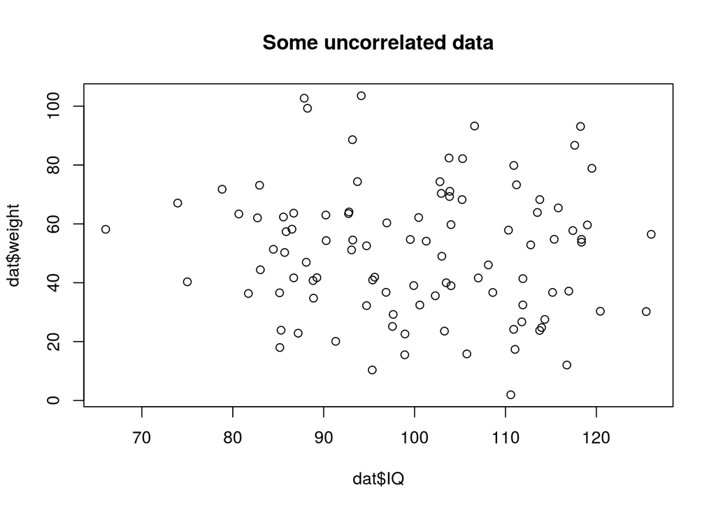

```r
## simulate some data in a data.frame
## rnorm draws samples from a normal distribution
set.seed(3) # this is a "random number seed" so that the simulation gives the same results when you repeat it
dat <- data.frame(
  IQ = rnorm(100,mean=100,sd=15),
  weight = rnorm(100,mean=50,sd=20),
  age = rnorm(100,mean=25,sd=3)
)
plot(dat$IQ,dat$weight,main="Some uncorrelated data")
```

## Running a regression analysis

Regression analysis is done through the `lm` function, with the following syntax: `lm(formula,data,...)`. The first argument is called `formula` and expects a symbolic description of your model. I will tell you more about how to specify models with the formula syntax later, when we discuss moderation. For now, a simple example will suffice. To specify a multiple regression model for a dependent variable named `y` and with three predictors, named `x1`, `x2`, and `x3`, you would use the formula

`y ~ x1 + x2 + x3`

The left-hand side of the formula gives the name of the dependent variable. After the name of the dependent variable, you need to put a tilde (`~`) (which you can read is “is modelled as a function of”). On the right-hand side, you provide the names of the predictors, separated by a `+` sign. R will automatically include an intercept in the model. In R, the intercept is actually represented as a special predictor which always (for every row in the data set) has the value 1. You can fit a model without an intercept (which is the same as fixing the value of the intercept to 0), by adding “-1” to the model formula, i.e.

`y ~ x1 + x2 + x3 - 1`

The second argument of the `lm` function is called `data` and expects the name of the data.frame in which the variables are stored. So, using the (uncorrelated) data simulated above, you could fit a regression model with IQ as dependent variable and weight and age as predictors as follows:

```r
mod <- lm(IQ~weight+age,data=dat)
mod
```

```
##
## Call:
## lm(formula = IQ ~ weight + age, data = dat)
##
## Coefficients:
## (Intercept)       weight          age
##   105.41985     -0.04141     -0.12505
```

Note that when you just print a fitted linear model (by e.g., typing the name of the object `mod`), R will show the parameter estimates, but nothing else. You can get the important statistics by calling the `summary` function on the fitted model:

```r
summary(mod)
```

```
##
## Call:
## lm(formula = IQ ~ weight + age, data = dat)
##
## Residuals:
##     Min      1Q  Median      3Q     Max
## -33.617 -10.240   0.125  10.589  26.076
##
## Coefficients:
##              Estimate Std. Error t value Pr(>|t|)
## (Intercept) 105.41985   11.33384   9.301 4.33e-15 ***
## weight       -0.04141    0.05918  -0.700    0.486
## age          -0.12505    0.42623  -0.293    0.770
## ---
## Signif. codes:  0 '***' 0.001 '**' 0.01 '*' 0.05 '.' 0.1 ' ' 1
##
## Residual standard error: 12.94 on 97 degrees of freedom
## Multiple R-squared:  0.005819,   Adjusted R-squared:  -0.01468
## F-statistic: 0.2839 on 2 and 97 DF,  p-value: 0.7535
```

The output of the `summary` function consists of four parts:

- `Call` simply shows you the call to the `lm` function used to fit the model (including the model formula)
- `Residuals` shows you some summary statistics for the prediction errors of the estimated model (which are often referred to as residuals)
- `Coefficients` shows you a table with:
  - the name of variable for which the parameter was estimated
  - `Estimate`: the estimated parameters
  - `Std. Error`: the standard error of the estimates (technically, this is the standard deviation of the sampling distribution of the estimate)
  - `t value`: a t statistic which corresponds to the hypothesis test that the parameter is equal to 0, so a model comparison between the model fitted (as MODEL A), and a model which fixes the parameter to 0. I.e. in the row named `weight` above, the following models are compared:
    - MODEL C: $\texttt{IQ}_i = \beta_0 + 0 \times \texttt{weight}_i + \beta_2 \times \texttt{age}_i + \epsilon_i$
    - MODEL A: $\texttt{IQ}_i = \beta_0 + \beta_1 \times \texttt{weight}_i + \beta_2 \times \texttt{age}_i + \epsilon_i$
  - `Pr(>|t|)`: the p-value, which is the probability that, given that MODEL C is actually true, you would find a t-statistic at least as extreme as the one computed found for this data.
- Some overall model statistics:
  - `Residual standard error`: this is $\sqrt{\text{MSE}(A)}$, where $\text{MSE}(A)$ is the mean squared error of the fitted model, i.e. $\text{MSE}(A) = \frac{\text{SSE}(A)}{n-\text{PA}}$
  - the $R^2$ and adjusted $R^2$ for the model
  - results of an overall model test where the model is compared to a MODEL C with only and intercept

The output that R gives you is pretty similar to the standard output that SPSS provides, although you’re missing the Sums of Squares for the overall model test. If you really want these, you can explictly perform the model comparison using the `anova` function, as I show below:

```r
# fit a MODEL C with only an intercept
mod0 <- lm(IQ ~ 1,data=dat)
anova(mod0,mod,test="F")
```

```
## Analysis of Variance Table
##
## Model 1: IQ ~ 1
## Model 2: IQ ~ weight + age
##   Res.Df   RSS Df Sum of Sq      F Pr(>F)
## 1     99 16325
## 2     97 16230  2    94.991 0.2839 0.7535
```

Under `RSS` you find the ‘residual Sum of Squares’, which is the SSE for the model. Under `Sum of Sq` R reports the Sum of Squares Reduced (SSR), so the difference between the two SSE terms. You will also find the F statistic and p-value for the whole model test.

A nice thing about R is that it is flexible, and if you’d rather see the $F$-statistics instead of the standard $t$-statistics for the tests of the intercepts and the slopes, that is possible. One way to obtain these is to use the `drop1` function, which creates a set of new models (which function as MODEL C) by dropping one parameter every time from the model (equivalent to fixing that parameter to 0). So, to get the $F$-test with our simulated data, you’d call:

```r
drop1(mod,test="F")
```

```
## Single term deletions
##
## Model:
## IQ ~ weight + age
##        Df Sum of Sq   RSS    AIC F value Pr(>F)
## <none>              16230 514.94
## weight  1    81.911 16312 513.45  0.4896 0.4858
## age     1    14.402 16244 513.03  0.0861 0.7699
```

## Saving residuals and predicted values

You can obtain the prediction errors by the calling the `residuals` function on the fitted model. You can obtain the predicted values by calling the `predict` function on the fitted model:

```r
# save the residuals as IqAgeWeight
IQAgeWeight <- residuals(mod)
# save the predictions as predIQ
predIQ <- predict(mod)
```

You can check that the residuals are computed as expected (up to computer precision):

```r
sum(dat$IQ - predIQ - IQAgeWeight)
```

```
## [1] -3.780531e-12
```

## Running a regression analysis in steps

If you want to add a new predictor (or set of predictors) to a model you already fitted, instead of retyping the complete model formula, you can also call the `update` function on the model, with the following syntax: `update(model,formula)`. If you first fit a model with weight as only predictor, and then want to add age as a predictor, you can do this as follows:

```r
mod1 <- lm(IQ ~ weight,data=dat)
mod1
```

```
##
## Call:
## lm(formula = IQ ~ weight, data = dat)
##
## Coefficients:
## (Intercept)       weight
##   102.23427     -0.04106
```

```r
mod2 <- update(mod1,formula=.~.+age)
mod2
```

```
##
## Call:
## lm(formula = IQ ~ weight + age, data = dat)
##
## Coefficients:
## (Intercept)       weight          age
##   105.41985     -0.04141     -0.12505
```

The `formula` is a bit different than before here. On the right-hand and left-hand side of the tilde (`~`), the dot (`.`) indicates that the same terms are inluded in the new model. So, the dot on the left-hand side represents `IQ` and the dot on the right-hand side represents `weight`. After the dot on the right-hand side, the `+age` represents that we want to add `age` as a predictor. You can also remove predictors this way, e.g.

```r
alsomod1 <- update(mod2,formula=.~.-age)
alsomod1
```

```
##
## Call:
## lm(formula = IQ ~ weight, data = dat)
##
## Coefficients:
## (Intercept)       weight
##   102.23427     -0.04106
```

Unfortunately, there is no easy way to do automatic model building based on $F$-tests in R. Automatic model building is implemented in the `stepAIC` function in the `MASS` package, but this is based on a different statistic (the so-called Akaike Information Criterion) rather than the F test. Due to the different statistics used, the results might differ somewhat from what SPSS provides.

To do a backwards search, starting from the full model, you can use

```r
library(MASS)
mod <- lm(IQ~weight+age,data=dat)
backward_mod <- stepAIC(mod,direction="backward")
```

```
## Start:  AIC=514.94
## IQ ~ weight + age
##
##          Df Sum of Sq   RSS    AIC
## - age     1    14.402 16244 513.03
## - weight  1    81.911 16312 513.45
## <none>                16230 514.94
##
## Step:  AIC=513.03
## IQ ~ weight
##
##          Df Sum of Sq   RSS    AIC
## - weight  1     80.59 16325 511.53
## <none>                16244 513.03
##
## Step:  AIC=511.53
## IQ ~ 1
```

```r
backward_mod
```

```
##
## Call:
## lm(formula = IQ ~ 1, data = dat)
##
## Coefficients:
## (Intercept)
##       100.2
```

```r
mod0 <- lm(IQ~1,data=dat) # intercept-only model
forward_mod <- stepAIC(mod0,scope=~weight+age,direction="forward")
```

```
## Start:  AIC=511.53
## IQ ~ 1
##
##          Df Sum of Sq   RSS    AIC
## <none>                16325 511.53
## + weight  1     80.59 16244 513.03
## + age     1     13.08 16312 513.45
```

The stepwise search (where you can add and remove variables) is done similarly as the forward method, but using a different direction argument:

```r
stepwise_mod <- stepAIC(mod0,scope=~weight+age,direction="both")
```

```
## Start:  AIC=511.53
## IQ ~ 1
##
##          Df Sum of Sq   RSS    AIC
## <none>                16325 511.53
## + weight  1     80.59 16244 513.03
## + age     1     13.08 16312 513.45
```

```r
stepwise_mod
```

```
##
## Call:
## lm(formula = IQ ~ 1, data = dat)
##
## Coefficients:
## (Intercept)
##       100.2
```

Note that, as the predictors are uncorrelated with the dependent variable, all methods end up with an intercept-only model for this simulated data. In the exercises, you should end up with a model with some predictors in!